# Chapter 05 - Inequalities

## 5. Inequalities

### 5.1 Markov and Chebyshev Inequalities

**Theorem 5.1 (Markov's Inequality)**. Let $X$ be a non-negative random variable and suppose that $\mathbb{E}(X)$ exists. For any $t > 0$,

$$ \mathbb{P}(X > t) \leq \frac{\mathbb{E}(X)}{t} $$

**Proof**.

$$ \mathbb{E}(X) =\int_0^\infty xf(x) dx =\int_0^t xf(x) dx + \int_t^\infty xf(x) dx \geq \int_t^\infty xf(x) dx \geq t \int_t^\infty f(x) dx = t \mathbb{P}(X > t) $$

**Theorem 5.2 (Chebyshev's Inequality)**. Let $\mu = \mathbb{E}(X)$ and $\sigma^2 = \mathbb{V}(X)$. Then,

$$ \mathbb{P}(|X - \mu| \geq t) \leq \frac{\sigma^2}{t^2} \quad \text{and} \quad \mathbb{P}(|Z| \geq k) \leq \frac{1}{k^2} $$

where $Z = (X - \mu) / \sigma$. In particular, $\mathbb{P}(|Z| > 2) \leq 1/4$ and $\mathbb{P}(|Z| > 3) \leq 1/9$.

**Proof**. We use Markov's inequality to conclude that

$$ \mathbb{P}(|X - \mu| \geq t) = \mathbb{P}(|X - \mu|^2 \geq t^2) \leq \left(\frac{\mathbb{E}(X - \mu)}{t}\right)^2 = \frac{\sigma^2}{t^2} $$

The second part follows by setting $t = k \sigma$.

### 5.2 Hoeffding's Inequality

Hoeffding's inequality is similar in spirit to Markov's inequality but it is a sharper inequality. We present the result here in two parts. The proofs are in the technical appendix.

**Theorem 5.4**. Let $Y_1, \dots, Y_n$ be independent observations such that $\mathbb{E}(Y_i) = 0$ and $a_i \leq Y_i \leq b_i$. Let $\epsilon > 0$. Then, for any $t > 0$,

$$ \mathbb{P}\left( \sum_{i=1}^n Y_i \geq \epsilon \right) \leq e^{-t\epsilon} \prod_{i=1}^n e^{t^2(b_i - a_i)^2 / 8} $$

**Theorem 5.5**. Let $X_1, \dots, X_n \sim \text{Bernoulli}(p)$. Then, for any $\epsilon > 0$,

$$ \mathbb{P}(|\overline{X}_n - p| > \epsilon) \leq 2e^{-2n\epsilon^2} $$

Hoeffding's inequality gives us a simple way go create a **confidence interval** for a binomial parameter $p$. We will discuss confidence intervals later but here is the basic idea. Let $\alpha > 0$ and let

$$ \epsilon_n = \left\{ \frac{1}{2n} \log \left( \frac{2}{\alpha} \right) \right\}^{1/2} $$

By Hoeffding's inequality,

$$ \mathbb{P}(|\overline{X}_n - p| > \epsilon_n) \leq 2e^{-2n\epsilon_n^2} = \alpha $$

Let $C = (\overline{X}_n - \epsilon, \overline{X}_n + \epsilon)$. Then, $\mathbb{P}(\text{not } C \in p) = \mathbb{P}(|\overline{X}_n - p| > \epsilon) \leq \alpha$. Hence, $\mathbb{P}(p \in C) \geq 1 - \alpha$, that is, the random interval $C$ traps the true parameter $p$ with probability $1 - \alpha$; we call $C$ a $1 - \alpha$ confidence interval. More on this later.

### 5.3 Cauchy-Schwartz and Jensen Inequalities

This section contains two inequalities on expected values that are often useful.

**Theorem 5.7 (Cauchy-Schwartz Inequalities)**. If $X$ and $Y$ have finite variances then

$$ \mathbb{E}|XY| \leq \sqrt{\mathbb{E}\left(X^2\right) \mathbb{E}\left(Y^2\right)} $$

Recall that a function $g$ is **convex** if for each $x, y$ and each $\alpha \in [0, 1]$,

$$ g(\alpha x + (1 - \alpha)y) \leq \alpha g(x) + (1 - \alpha) g(y) $$

**Theorem 5.8 (Jensen's Inequality)**. If $g$ is convex then

$$ \mathbb{E}g(X) \geq g(\mathbb{E}X) $$

If $g$ is concave then

$$ \mathbb{E}g(X) \leq g(\mathbb{E}X) $$

**Proof**. Let $L(x) = a + bx$ be a line, tangent to the $g(x)$ at the point $\mathbb{E}(X)$. Since $g$ is convex, it lies above the line $L(x)$. So,

$$ \mathbb{E}g(X) \geq \mathbb{E}L(X) = \mathbb{E}(a + bX) = a + b\mathbb{E}(X) = L(\mathbb{E}(X)) = g(\mathbb{E}(X))$$

From Jensen's inequality we see that $\mathbb{E}X^2 \geq (\mathbb{E}X)^2$ and $\mathbb{E}(1/X) \geq 1 / \mathbb{E}(X)$. Since log is concave, $\mathbb{E}(\log X) \leq \log \mathbb{E}(X)$. For example, suppose that $X \sim N(3, 1)$. Then $\mathbb{E}(1 / X) \geq 1/3$.

### 5.4 Technical Appendix: Proof of Hoeffding's Inequality

We will make use of the exact form of Taylor's theorem: if $g$ is a smooth function, then there is a number $\xi \in (0, u)$ such that $g(u) = g(0) + u g'(0) + \frac{u^2}{2}g''(\xi)$.

**Proof of Theorem 5.4**. For any $t > 0$, we have, from Markov's inequality, that

$$ \mathbb{P}\left( \sum_{i=1}^n Y_i \geq \epsilon \right) = \mathbb{P}\left( t \sum_{i=1}^n Y_i \geq t \epsilon \right) = \mathbb{P}\left( e^{t \sum_{i=1}^n Y_i} \geq e^{t \epsilon} \right) \leq e^{-t\epsilon} \mathbb{E}\left( e^{t \sum_{i=1}^n Y_i}\right) = e^{-t\epsilon} \prod_i \mathbb{E}\left(e^{tY_i}\right) $$

Since $a_i \leq Y_i \leq b_i$, we can write $Y_i$ as a convex combination of $a_i$ and $b_i$, namely, $Y-i = \alpha b_i + (1 - \alpha) a_i$ where $\alpha = (Y_i - a_i) / (b_i - a_i)$. So, by the convexity of $e^{ty}$ we have

$$ e^{tY_i} \leq \frac{Y_i - a_i}{b_i - a_i} e^{tb_i} + \frac{b_i - Y_i}{b_i - a_i} e^{ta_i} $$

Take expectations of both sides and use the fact that $\mathbb{E}(Y_i) = 0$ to get

$$ \mathbb{E}e^{tY_i} \leq - \frac{a_i}{b_i - a_i} e^{tb_i} + \frac{b_i}{b_i - a_i} e^{ta_i} = e^{g(u)} $$

where $u = t(b_i - a_i)$, $g(u) = -\gamma u + \log (1 - \gamma + \gamma e^u)$ and $\gamma = -a_i / (b_i - a_i)$.

Note that $g(0) = g'(0) = 0$. Also, $g''(u) \leq 1/4$ for all $u > 0$. By Taylor's theorem, there is a $\xi \in (0, u)$ such that

$$ g(u) = g(0) + u g'(0) + \frac{u^2}{2} g(\xi) = \frac{u^2}{2} g(\xi) \leq \frac{u^2}{8} = \frac{t^2(b_i - a_i)^2}{8} $$

Hence,

$$ \mathbb{E}e^{tY_i} \leq e^{g(u)} \leq e^{t^2(b_i - a_i)^2/8} $$

and the result follows.

**Proof of Theorem 5.5**. Let $Y_i = (1 / n)(X_i - p)$. Then $\mathbb{E}(Y_i) = 0$ and $a \leq Y_i \leq b$ where $a = -p/n$ and $b = (1 - p) / n$. Also, $(b - a)^2 = 1/n^2$. Applying Theorem 5.4 we get

$$ \mathbb{P}\left(\overline{X}_n - p > \epsilon\right) = \mathbb{P}\left( \sum_i Y_i > \epsilon \right) \leq e^{-t\epsilon} e^{t^2/(8n)}$$

The above holds for any $t > 0$. In particular, take $t = 4n\epsilon$ and we get $\mathbb{P}\left(\overline{X}_n - p > \epsilon\right) \leq e^{-2n\epsilon^2}$. By a similar argument we can show that $\mathbb{P}\left(\overline{X}_n - p < \epsilon\right) \leq e^{-2n\epsilon^2}$. Putting those together we get $\mathbb{P}\left(|\overline{X}_n - p| > \epsilon\right) \leq 2e^{-2n\epsilon^2}$.

### 5.6 Exercises

**Exercise 5.6.1**. Let $X \sim \text{Exponential}(\beta)$. Find $\mathbb{P}(|X - \mu_X| > k \sigma_X)$ for $k > 1$. Compare this to the bound you get from Chebyshev's inequality.

**Solution**.

Let $F$ be the CDF of $X$. We have:

$$ \begin{align} \mathbb{P}(|X - \mu_X| > k \sigma_X) &= 1 - \mathbb{P}(-k \sigma_X < X - \mu_X < k \sigma_X) \\ &= 1 - \mathbb{P}(\mu_X - k \sigma_X < X < \mu_X + k \sigma_X) \\ &= 1 - F(\mu_X + k \sigma_X) + F(\mu_X - k \sigma_X) \\ &= 1 - 1 + \exp\left\{ -\frac{\left(\beta + k \beta\right)^+}{\beta} \right\} + 1 - \exp\left\{-\frac{\left(\beta - k \beta\right)^+}{\beta} \right\} \\ &= 1 + e^{-(1+k)^+ } - e^{-(1-k)^+} \end{align} $$

where $(a)^+ = \max \{ a, 0 \}$.

On the other hand, Chebyshev's bound provides, for $t = k\sigma_X$,

$$ \mathbb{P}(|X - \mu_X| \geq k \sigma_X) \leq \frac{\sigma_X^2}{k^2 \sigma_X^2} = \frac{1}{k^2} $$

which is a weaker bound.

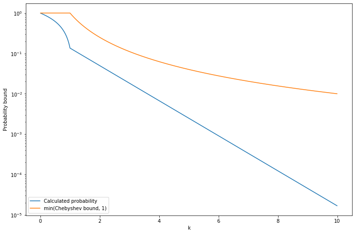

```python
import numpy as np
import matplotlib.pyplot as plt
%matplotlib inline

def f(k):
    return 1 + np.exp(-np.maximum(1+k, 0)) - np.exp(-np.maximum(1 - k, 0))

def chebyshev(k):
    # Limit upper bound to 1, since probability is always under 1
    return np.minimum(1 / (k**2), 1)

kk = np.arange(0.01, 10, step = 0.01)

plt.figure(figsize=(12, 8))

plt.plot(kk, f(kk), label='Calculated probability')
plt.plot(kk, chebyshev(kk), label='min(Chebyshev bound, 1)')
plt.yscale('log')
plt.xlabel('k')
plt.ylabel('Probability bound')
plt.legend(loc='lower left')
plt.show()
```

**Exercise 5.6.2**. Let $X \sim \text{Poisson}(\lambda)$. Use Chebyshev's inequality to show that $\mathbb{P}(X \geq 2\lambda) \leq 1 / \lambda$.

**Solution**. We have $\mu_X = \lambda$ and $\sigma_X^2 = \lambda$, so Chebyshev's gives us:

$$ \mathbb{P}(|X - \lambda| \geq t) \leq \frac{\lambda}{t^2} $$

If we make $t = \lambda$, we get

$$ \mathbb{P}(X \geq \lambda) = \mathbb{P}(|X - \lambda| \geq \lambda) \leq \frac{1}{\lambda} $$

**Exercise 5.6.3**. Let $X_1, \dots, X_n \sim \text{Bernoulli}(p)$ and $\overline{X}_n = n^{-1} \sum_{i=1}^n X_i$. Bound $\mathbb{P}(|\overline{X}_n - p| > \epsilon)$ using Chebyshev's inequality and using Hoeffding's inequality.

Show that, when $n$ is large, the bound from Hoeffding's inequality is smaller than the bound from Chebyshev's inequality.

**Solution**. Note that $\mathbb{E}(\overline{X}_n) = p$ and $\mathbb{V}(\overline{X}_n) = p(1-p) / n$, since $n \overline{X}_n \sim \text{Binomial}(n, p)$.

Using Chebyshev's inequality,

$$ \mathbb{P}(|\overline{X}_n - p| \geq \epsilon) \leq \frac{p(1 - p)}{n \epsilon^2} $$

Using Hoeffding's inequality,

$$ \mathbb{P}(|\overline{X}_n - p| > \epsilon) \leq 2e^{-2n\epsilon^2} $$

The bound provided by Hoeffding's inequality is $O(e^{-2n\epsilon^2})$, while the bound provided by Chebyshev's inequality is $O(n^{-1})$, therefore the bound from Hoeffding's inequality is smaller for a sufficiently large $n$.

**Exercise 5.6.4**. Let $X_1, \dots, X_n \sim \text{Bernoulli}(p)$.

**(a)** Let $\alpha > 0$ be fixed and define

$$ \epsilon_n = \sqrt{\frac{1}{2n} \log \left( \frac{2}{\alpha}\right)} $$

Let $\hat{p}_n = n^{-1} \sum_{i=1}^n X_i$. Define $C_n = (\hat{p}_n - \epsilon_n, \hat{p}_n + \epsilon_n)$. Use Hoeffding's inequality to show that

$$ \mathbb{P}(p \in C_n) \geq 1 - \alpha $$

We call $C_n$ a *$1 - \alpha$ confidence interval for $p$*. In practice, we truncate the interval so it does not go below 0 or above 1.

**(b) (Computer Experiment)** Let's examine the properties of this confidence interval. Let $\alpha = 0.05$ and $p = 0.4$. Conduct a simulation study to see how often the interval contains $p$ (called the coverage). Do this for various values of $n$ between 1 and 10000. Plot the coverage versus $n$.

**(c)** Plot the length of the interval versus $n$. Suppose we want the length of the interval to be no more than .05. How large should $n$ be?

**Solution**.

**(a)** The result is immediate from replacing $\epsilon_n$ into Hoeffding's inequality,

$$ \mathbb{P}(|\hat{p}_n - p| > \epsilon_n) \leq 2e^{-2n\epsilon_n^2} = \alpha $$

since $\mathbb{E}(\hat{p}_n) = p$.

**(b)**

```python
import numpy as np
from scipy.stats import bernoulli
from tqdm import tqdm_notebook

alpha = 0.05
p = 0.4

B = 50000
N = 10000

nn = np.arange(1, N + 1)
epsilon_n = np.sqrt((1 / (2 * nn)) * np.log(2 / alpha))

p_hat = np.empty((B, N))
for i in tqdm_notebook(range(B)):
    X = bernoulli.rvs(p, size=N, random_state=i)
    p_hat[i] = np.cumsum(X) / nn

coverage = np.mean((p_hat + epsilon_n >= p) & (p_hat - epsilon_n <= p), axis=0)
```

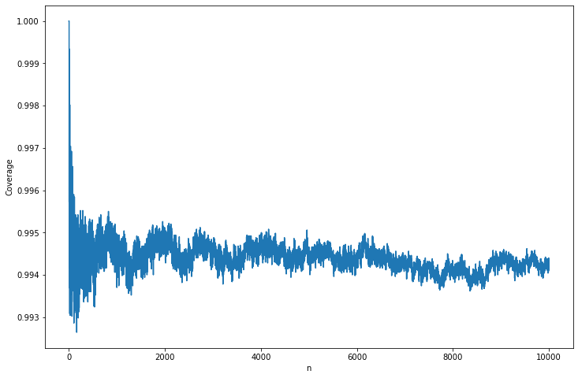

```python
import matplotlib.pyplot as plt
%matplotlib inline

plt.figure(figsize=(12, 8))
plt.plot(nn, coverage)
plt.xlabel('n')
plt.ylabel('Coverage')
plt.show()
```

**(c)** The length of the interval is $\min \{\hat{p}_n + \epsilon_n, 1 \} - \max \{ \hat{p}_n - \epsilon_n, 0\}$. As $\hat{p}_n \rightarrow p$, let's plot the approximation on the limit case, which is just $2 \epsilon_n$.

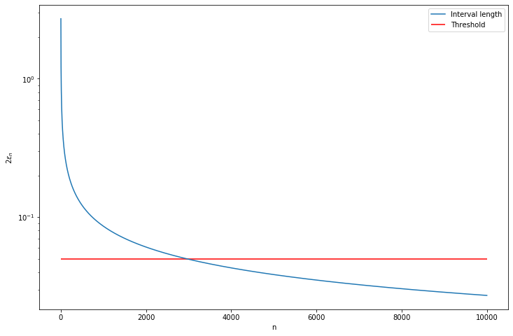

```
Smallest n with interval length under .05: 2952
```

```python
plt.figure(figsize=(12, 8))
plt.plot(nn, 2 * epsilon_n, label='Interval length')
plt.xlabel('n')
plt.ylabel(r'$2\epsilon_n$')
plt.hlines(.05, xmin=0, xmax=N, color='red', label='Threshold')
plt.yscale('log')
plt.legend(loc='upper right')
plt.show()

selected_n = nn[np.argmax(2 * epsilon_n <= .05)]
print('Smallest n with interval length under .05: %i' % selected_n)
```